# Ensemble methods

Alex Savenkov

05/23/2017

# Intro

Consider a standard supervised learning problem

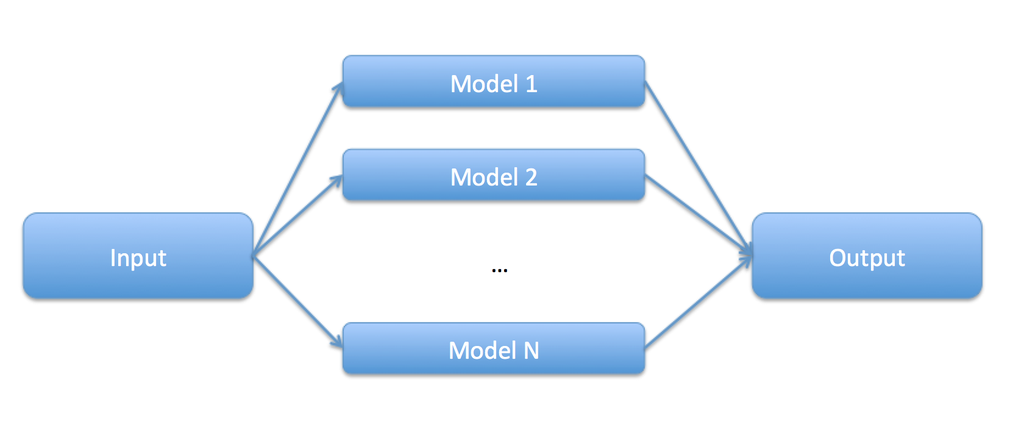

# Ensemble

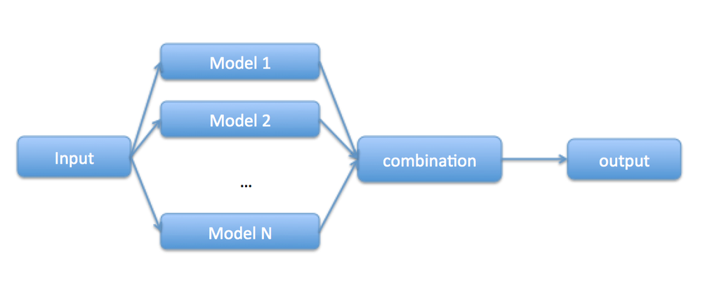

# pros and cons

- benefits
  - good generalization ability
- challenges
  - computationally expensive

# Ensemble learning models

- boosting
- bagging
- random forests

# Methods

- averaging
- voting
- stacking

# Averaging

- averaging is the most popular and fundamental combination method
- suppose we have set of learners $\{h_1, h_2,...,h_N\}$, then combined output $H(x)$ is given by
  $$H(x) = \frac{1}{N}\sum_{i=1}^Nh_i(x)$$
- weighted average is given by
  $$H(x) =\sum_{i=1}^N w_ih_i(x) \quad \text{with} \ w_i \geq 0 \ \text{and} \ \sum_{i=1}^Nw_i = 1$$

# Voting (example)

- consider classification problem with 10 samples with responses: $Y = (1, 1, 1, 1, 1, 1, 1, 1, 1, 1)$
- three learners: M1, M2, M3
- all three classifiers have 0.7 accuracy

# Voting (cont.)

- P(all three correct) = $0.7\times0.7\times0.7 = 0.343$
- P(two correct) = $3\times0.3\times0.7\times0.7 = 0.441$
- P(at least two correct) = 0.784

# Correlation

- highly correlated
  - M1: $(1, 1, 1, 1, 1, 1, 1, 0, 0, 0)$
  - M2: $(1, 1, 1, 1, 0, 1, 1, 0, 1, 0)$
  - M3: $(1, 1, 1, 1, 1, 1, 0, 0, 0, 1)$
  - E1: $(1, 1, 1, 1, 1, 1, 1, 0, 0, 0)$
  - ensemble accuracy - 0.7

# Correlation

- less correlated
  - M1: $(1, 0, 0, 1, 1, 1, 1, 1, 0, 1)$
  - M2: $(1, 1, 1, 1, 0, 0, 1, 1, 1, 0)$
  - M3: $(1, 1, 1, 0, 1, 1, 0, 1, 0, 1)$
  - E1: $(1, 1, 1, 1, 1, 1, 1, 1, 0, 1)$
  - ensemble accuracy - 0.9

# Stacking

- Stacking is a general procedure where a learner is trained to combine the individual learners.
- individual learners are called the *first-level learners*
- a model that combines first-level learners is called a *meta-learner*

# SuperLearner

- let $Y$ - vector of responses and $X$ - covariates
- $h_1,...,h_L$ - set of base learners
- create matrix $Z$ where each column is cross-validated predictions of the base learners
  - for each validation set $v \in \{1,..., V\}$ train learner $h_l$ on $\{1,..., V\}\setminus v$ and then predict using subset $v$
- estimate a meta-learner $H$ based on matrix $Z$ and $Y$

# Packages

- caret
- SuperLearner
- caretEnsemble

# caret

- data splitting
- pre-processing
- feature selection
- model tuning using resampling
- variable importance estimation

# example with caretEnsemble

Data: Sonar from **mlbench**:

- 60 covariates, 208 observations, response - $\{0, 1\}$

```
##        V1     V2     V3     V4     V5     V6
## 1  0.0200 0.0371 0.0428 0.0207 0.0954 0.0986
## 2  0.0453 0.0523 0.0843 0.0689 0.1183 0.2583
## 3  0.0262 0.0582 0.1099 0.1083 0.0974 0.2280
## 4  0.0100 0.0171 0.0623 0.0205 0.0205 0.0368
## 5  0.0762 0.0666 0.0481 0.0394 0.0590 0.0649
## 6  0.0286 0.0453 0.0277 0.0174 0.0384 0.0990
## 7  0.0317 0.0956 0.1321 0.1408 0.1674 0.1710
## 8  0.0519 0.0548 0.0842 0.0319 0.1158 0.0922
## 9  0.0223 0.0375 0.0484 0.0475 0.0647 0.0591
## 10 0.0164 0.0173 0.0347 0.0070 0.0187 0.0671
```

# example (cont.)

```r
set.seed(107)
model_list <- caretList(
  Class~., data=training,
  trControl=my_control,
  methodList=c("rf", "gbm", "rpart")
)
```

Correlation between models

```
##              rf       gbm     rpart
## rf    1.0000000 0.6447882 0.3250142
## gbm   0.6447882 1.0000000 0.1658579
## rpart 0.3250142 0.1658579 1.0000000
```

# example (cont.)

```r
glm_ensemble <- caretStack(
  model_list,
  method="glm",
  metric="ROC",
  trControl=trainControl(
    method="boot",
    number=10,
    savePredictions="final",
    classProbs=TRUE,
    summaryFunction=twoClassSummary
  )
)
model_preds$ensemble <- predict(glm_ensemble,
                                newdata=testing, type="prob")
```

```
##               rf       gbm     rpart  ensemble
## M vs. R 0.945216 0.8919753 0.6566358 0.9552469
```

```r
set.seed(107)
model_list <- caretList(
  Class~., data=training,
  trControl=my_control,
  methodList=c("rf", "gbm")
)
```

```r
glm_ensemble <- caretStack(
  model_list,
  method="glm",
  metric="ROC",
  trControl=trainControl(
    method="boot",
    number=10,
    savePredictions="final",
    classProbs=TRUE,
    summaryFunction=twoClassSummary
  )
)
model_preds$ensemble <- predict(glm_ensemble,
                                newdata=testing, type="prob")
```

```
##               rf       gbm  ensemble
## M vs. R 0.945216 0.8919753 0.9429012
```

```r
set.seed(107)
model_list <- caretList(
  Class~., data=training,
  trControl=my_control,
  methodList=c("rf", "rpart")
)
```

```r
glm_ensemble <- caretStack(
  model_list,
  method="glm",
  metric="ROC",
  trControl=trainControl(
    method="boot",
    number=10,
    savePredictions="final",
    classProbs=TRUE,
    summaryFunction=twoClassSummary
  )
)
model_preds$ensemble <- predict(glm_ensemble,
                                newdata=testing, type="prob")
```

```
##               rf     rpart  ensemble
## M vs. R 0.945216 0.6566358 0.9506173
```

# References

1. L. Breiman. Stacked regressions. *Machine Learning*, 24(1):49-64, 1996
2. Wolpert, D. H. The supervised learning no-free-lunch theorems. In *Soft computing and industry*, pages 25-42, 2002
3. van der Laan, M. J., Polley, E. C., and Hubbard, A. E. *Super learner*. Statistical applications in genetics and molecular biology 6, 2007
4. **caret** package http://topepo.github.io/caret/index.html
5. **caretEnsemble** package https://cran.r-project.org/web/packages/caretEnsemble/